# Segmentación de imágenes

Laboratorio 3

Dr. Alejandro Veloz

alejandro.veloz@uv.cl

Ingeniería Biomédica  
Universidad de Valparaíso - Chile

## Objetivos

Los objetivos de esta actividad son los siguientes:

- Implementar *workflows* que permitan **segmentar** estructuras de interés en imágenes médicas usando diferentes algoritmos.
- Comparar distintas segmentaciones mediante métricas cuantitativas.
- Analizar resultados en varios sujetos.

## Datos

Se trabajará con datos de pacientes que sufren esclerosis múltiple: [Open MS data](https://github.com/muschellij2/open_ms_data/tree/master/cross_sectional/raw)

## Datos

Paciente 4 - Anatomía, slice 312

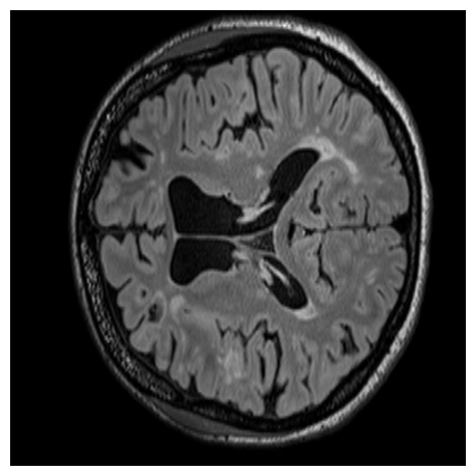

Paciente 4 - Anatomía + Gold Standard, slice 312

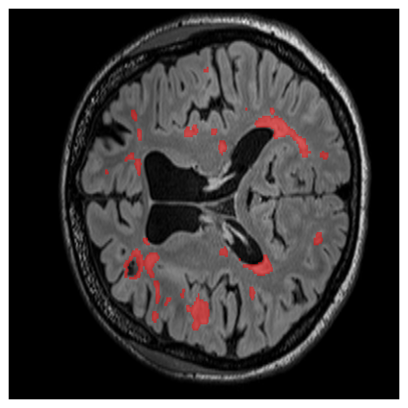

## Actividad

- Desarrolle *workflows* para la segmentación de esclerosis múltiple usando los algoritmos: k-means, fuzzy k-means, mezclas gaussianas mediante EM y crecimiento de regiones (*region growing*).
- Todos los *workflows* deben considerar mejoras de contraste y filtros adecuados. Esta etapa puede ser común para todos los *workflows*.
- Mejore los resultados obtenidos usando un MRF.
- Compare cuantitativamente los distintos *workflows* implementados. Analice los resultados.

*Nota:*

- Puede emplear las librerías que considere pertinentes para el desarrollo de los *workflows*. Explique el funcionamiento de todas las funciones utilizadas.
- Es necesario analizar el efecto de los principales parámetros de cada técnica de segmentación para una correcta comparación cuantitativa.

## Instrucciones para la entrega

- *apellido_nombre_l3.ipynb* y *apellido_nombre_l3.pdf*
- Medio: Aula virtual
- Las versiones *.pdf* en las entregas corresponden a los archivos *.ipynb* con las salidas de las celdas visibles.
- No respetar las instrucciones significará un descuento de 10 pts.